# Functions and Tidy Data

Wendi White

10/5/2020

github: https://github.com/wendi-white/biol607_homework

```r
#libraries
library(visdat)
library(skimr)
library(lubridate)
library(dplyr)
```

```r
library(stringr)
library(tidyr)
library(ggplot2)
library(matrixStats)
```

1. Write a function that takes a vector and returns one bootstrapped sample from said vector. Demonstrate that it works.

```r
boot_samp <- function(my_vec) { #creat a function that takes vector (my_vec) and takesn one boostrapped sample one time with replacement
  out <- sample(my_vec,
                    size=length(my_vec),
                    replace = TRUE)
  return(out) #return the new smaple
  }

boot_samp(c(1,4,5,2,4,5,6,1,3)) #test
```

```
## [1] 1 5 1 2 2 1 4 6 3
```

2. Write a function that given a vector of values a request for some number of bootstraps (let’s call the parameter R), and a sample statistic function (e.g., mean, IQR, etc.) returns R number of values of that statistic. Have it default to R = 1000 and the function is mean. Show this works for 10 bootstrapped replicate draws of a mean from some vector. Do the values look reasonable? Compare to the actual mean of the vector. Make sure you are using the function(s) you wrote in #1

```r
boot_samp <- function(my_vec, R=1000) { #write a function that given a vector will request for R # (1000) of bootstraps
  out <- replicate(R, sample(my_vec, #will return R # of statistic functions (mean)
                    size=length(my_vec),
                    replace = TRUE) %>% mean)
  return(out)
}
boot_samp(c(1,4,5,2,4,5,6,1,3), R=10) #give vector and set sample size at 10 not 1000
```

```
##  [1] 2.888889 3.222222 3.111111 3.555556 3.777778 3.000000 3.111111 3.222222
##  [9] 2.888889 4.333333
```

```r
mean(c(1,4,5,2,4,5,6,1,3)) #actual mean of vector is 3.444444
```

```
## [1] 3.444444
```

```r
mean(c(3.444444, 3.333333, 3.666667, 5.222222, 3.888889, 3.222222, 4.000000, 3.555556, 3.666667, 4)) #just testing the mean of the bootstrapped samples
```

```
## [1] 3.8
```

```r
#got help from Jarrett and talked about functions. Think I understand them better so
#redid problem to check this work after
boot_samp_new <- function(boot_samp, R=1000, stat_funky=mean){
  out <- replicate(R, boot_samp %>% stat_funky)
  return(out)
}

boot_samp_new(c(1,5,10,1,2,13,100), R=10)
```

```
##  [1] 18.85714 18.85714 18.85714 18.85714 18.85714 18.85714 18.85714 18.85714
##  [9] 18.85714 18.85714
```

3. Write a function that, given a vector of values a request for some number of bootstraps, and a sample statistic function, returns the original value of the statistic as applied to the vector, the mean of the statistic generated by the bootstrapped reps, the upper and lower 95% CI of the bootstrapped statistic (e.g., the 0.025 and 0.975 quantile), and the bias (i.e., the original value of the statistic - the mean of the bootstrapped statistic). make sure you are using the function(s) you wrote in #1 and/or #2

```r
boot_samp <- function(my_vec, R=1000) { #write a function that given a vector will request for R # (1000) of bootstraps
  out <- replicate(R, sample(my_vec, #will return R # of statistic functions (mean)
                    size=length(my_vec),
                    replace = TRUE) %>% mean)
  return(out)
}
boot_samp(c(1,4,5,2,4,5,6,1,3)) #1000 means from a given vector
```

```
##    [1] 2.888889 3.000000 2.777778 4.333333 3.222222 3.222222 3.666667 4.888889
##    [9] 3.555556 4.333333 3.444444 2.777778 3.000000 4.111111 4.222222 3.111111
##   [17] 3.888889 2.777778 3.111111 4.111111 2.666667 3.333333 2.444444 2.777778
##   [25] 2.000000 4.000000 3.777778 4.777778 3.444444 2.666667 3.222222 4.000000
##   [33] 3.888889 2.888889 3.555556 3.222222 3.666667 3.444444 3.888889 2.666667
##   [41] 3.666667 3.333333 3.444444 3.222222 3.000000 3.555556 4.000000 4.111111
##   [49] 3.444444 3.111111 3.777778 3.666667 5.000000 4.000000 3.555556 3.888889
##   [57] 2.555556 3.222222 3.666667 3.444444 3.666667 4.111111 3.333333 3.666667
##   [65] 3.666667 3.222222 4.111111 3.666667 3.333333 2.666667 3.888889 3.222222
##   [73] 3.000000 2.444444 3.000000 2.555556 4.222222 3.444444 3.222222 3.111111
##   [81] 3.666667 2.888889 3.777778 3.777778 3.000000 3.888889 3.555556 3.222222
##   [89] 3.555556 2.777778 4.000000 3.777778 2.888889 3.666667 2.222222 2.555556
##   [97] 2.777778 4.111111 3.666667 4.666667 3.111111 3.111111 3.666667 3.222222
##  [105] 3.333333 3.444444 3.777778 3.111111 3.555556 3.777778 2.777778 4.000000
##  [113] 3.555556 3.555556 2.444444 3.000000 3.222222 3.000000 4.444444 3.333333
```

[output cut: 110 more lines]

```r
#returns the original value of the mean as applied to the vector
mean_of_vec <- function(my_vec) {
  out_2 <- mean(my_vec)
  return(out_2)
}
mean_of_vec(c(1,4,5,2,4,5,6,1,3))
```

```
## [1] 3.444444
```

```r
#returns the mean of the statistic generated by the bootstrapped reps,
mean_of_boot <- function(my_vec, R=1000) { #write a function that given a vector will request for R # (1000) of bootstraps
  out <- replicate(R, sample(my_vec, #will return R # of statistic functions (mean)
                    size=length(my_vec),
                    replace = TRUE) %>% mean)
  m <- mean(out)
  return(m)
}
mean_of_boot(c(1,4,5,2,4,5,6,1,3))
```

```
## [1] 3.423778
```

```r
#returns the upper and lower 95% CI of the bootstrapped statistic (e.g., the 0.025 and 0.975 quantile),
quantiles_of_boot <- function(my_vec, R=1000) {
  out <- replicate(R, sample(my_vec,
                    size=length(my_vec),
                    replace = TRUE) %>% mean)
  quants <- quantile(out, probs = 0.025) #calls to return lower quant of bootstrapped stat
  return(quants)
}
quantiles_of_boot(c(1,4,5,2,4,5,6,1,3))
```

```
##     2.5%
## 2.333333
```

```r
quantiles_of_boot_up <- function(my_vec, R=1000) {
  out <- replicate(R, sample(my_vec,
                    size=length(my_vec),
                    replace = TRUE) %>% mean)
  quants_up <- quantile(out, probs = 0.975) ##return upper quant of bootstrapped stat
  return(quants_up)
}
quantiles_of_boot_up(c(1,4,5,2,4,5,6,1,3))
```

```
##    97.5%
## 4.555556
```

```r
#equation for mean of vec- mean of bootstrapped vec
bias_samp <- mean_of_vec(c(1,4,5,2,4,5,6,1,3)) - mean_of_boot(c(1,4,5,2,4,5,6,1,3))



boot_samp_three <- function(boot_samp, R=1000, stat_funky=mean){
  out <- replicate(R, boot_samp %>% stat_funky)
  return(out)
}

boot_samp_new(c(1,5,10,1,2,13,100), R=10)
```

```
##  [1] 18.85714 18.85714 18.85714 18.85714 18.85714 18.85714 18.85714 18.85714
##  [9] 18.85714 18.85714
```

4. FiveThirtyEight keeps a great archive of poll data at https://projects.fivethirtyeight.com/polls/. The presidential general election polling data is freely available at https://projects.fivethirtyeight.com/polls-page/president_polls.csv with question, poll id, and cycle defining a unique poll.

   4a. Download and look at the data. Is it long or wide?

   Data is long b/c each row is its own data point.

```r
election_data <- read.csv("https://projects.fivethirtyeight.com/polls-page/president_polls.csv")
names(election_data)
```

```
##  [1] "question_id"               "poll_id"
##  [3] "cycle"                     "state"
##  [5] "pollster_id"               "pollster"
##  [7] "sponsor_ids"               "sponsors"
##  [9] "display_name"              "pollster_rating_id"
## [11] "pollster_rating_name"      "fte_grade"
## [13] "sample_size"               "population"
## [15] "population_full"           "methodology"
## [17] "office_type"               "seat_number"
## [19] "seat_name"                 "start_date"
## [21] "end_date"                  "election_date"
## [23] "sponsor_candidate"         "internal"
## [25] "partisan"                  "tracking"
## [27] "nationwide_batch"          "ranked_choice_reallocated"
## [29] "created_at"                "notes"
## [31] "url"                       "stage"
## [33] "race_id"                   "answer"
## [35] "candidate_id"              "candidate_name"
## [37] "candidate_party"           "pct"
```

```r
str(election_data)
```

```
## 'data.frame':    9414 obs. of  38 variables:
##  $ question_id              : int  132342 132342 132340 132340 132335 132335 132335 132324 132324 132324 ...
##  $ poll_id                  : int  70744 70744 70742 70742 70738 70738 70738 70733 70733 70733 ...
##  $ cycle                    : int  2020 2020 2020 2020 2020 2020 2020 2020 2020 2020 ...
##  $ state                    : chr  "Florida" "Florida" "" "" ...
##  $ pollster_id              : int  1102 1102 568 568 1424 1424 1424 228 228 228 ...
##  $ pollster                 : chr  "Emerson College" "Emerson College" "YouGov" "YouGov" ...
##  $ sponsor_ids              : chr  "" "" "1213" "1213" ...
##  $ sponsors                 : chr  "" "" "Yahoo News" "Yahoo News" ...
##  $ display_name             : chr  "Emerson College" "Emerson College" "YouGov" "YouGov" ...
##  $ pollster_rating_id       : int  88 88 391 391 448 448 448 144 144 144 ...
##  $ pollster_rating_name     : chr  "Emerson College" "Emerson College" "YouGov" "YouGov" ...
##  $ fte_grade                : chr  "A-" "A-" "B" "B" ...
##  $ sample_size              : int  690 690 NA NA 789 789 789 851 851 851 ...
##  $ population               : chr  "lv" "lv" "lv" "lv" ...
```

[output cut: 24 more lines]

```r
summary(election_data)
```

```
##   question_id        poll_id          cycle         state
##  Min.   : 92078   Min.   :57025   Min.   :2020   Length:9414
##  1st Qu.:114010   1st Qu.:62674   1st Qu.:2020   Class :character
##  Median :124601   Median :66723   Median :2020   Mode  :character
##  Mean   :119593   Mean   :65523   Mean   :2020
##  3rd Qu.:129484   3rd Qu.:69504   3rd Qu.:2020
##  Max.   :132342   Max.   :70744   Max.   :2020
##
##   pollster_id     pollster         sponsor_ids          sponsors
##  Min.   :  11   Length:9414        Length:9414        Length:9414
##  1st Qu.: 568   Class :character   Class :character   Class :character
##  Median :1189   Mode  :character   Mode  :character   Mode  :character
##  Mean   :1015
##  3rd Qu.:1416
##  Max.   :1629
##
##  display_name       pollster_rating_id pollster_rating_name  fte_grade
##  Length:9414        Min.   :  3.0      Length:9414          Length:9414
##  Class :character   1st Qu.:154.0      Class :character     Class :character
##  Mode  :character   Median :267.0      Mode  :character     Mode  :character
##                     Mean   :279.9
##                     3rd Qu.:387.5
##                     Max.   :624.0
##                     NA's   :4
##   sample_size      population        population_full    methodology
##  Min.   :    88   Length:9414        Length:9414        Length:9414
##  1st Qu.:   743   Class :character   Class :character   Class :character
##  Median :  1000   Mode  :character   Mode  :character   Mode  :character
##  Mean   :  2155
##  3rd Qu.:  1413
##  Max.   :152640
##  NA's   :4
##  office_type         seat_number seat_name       start_date
##  Length:9414        Min.   :0    Mode:logical   Length:9414
##  Class :character   1st Qu.:0    NA's:9414      Class :character
##  Mode  :character   Median :0                   Mode  :character
##                     Mean   :0
##                     3rd Qu.:0
##                     Max.   :0
##
```

[output cut: 25 more lines]

```
##  Min.   :6210   Length:9414        Min.   :13253   Length:9414
##  1st Qu.:6210   Class :character   1st Qu.:13254   Class :character
##  Median :6220   Mode  :character   Median :13256   Mode  :character
##  Mean   :6250                      Mean   :13346
##  3rd Qu.:6244                      3rd Qu.:13256
##  Max.   :8718                      Max.   :16083
##
##  candidate_party         pct
##  Length:9414        Min.   : 0.00
##  Class :character   1st Qu.:40.98
##  Mode  :character   Median :45.00
##                     Mean   :42.61
##                     3rd Qu.:49.00
##                     Max.   :90.53
##
```

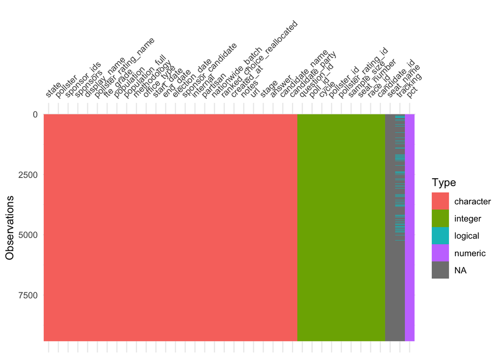

```r
vis_dat(election_data)
```

```r
skim(election_data)
```

Data summary

| Name | election_data |
| --- | --- |
| Number of rows | 9414 |
| Number of columns | 38 |
| _______________________ |  |
| Column type frequency: |  |
| character | 26 |
| logical | 2 |
| numeric | 10 |
| ________________________ |  |
| Group variables | None |

**Variable type: character**

| skim_variable | n_missing | complete_rate | min | max | empty | n_unique | whitespace |
| --- | --- | --- | --- | --- | --- | --- | --- |
| state | 0 | 1 | 0 | 20 | 3802 | 56 | 0 |
| pollster | 0 | 1 | 4 | 76 | 0 | 186 | 0 |
| sponsor_ids | 0 | 1 | 0 | 18 | 5094 | 191 | 0 |
| sponsors | 0 | 1 | 0 | 80 | 5094 | 191 | 0 |
| display_name | 0 | 1 | 4 | 76 | 0 | 199 | 0 |
| pollster_rating_name | 0 | 1 | 0 | 76 | 4 | 186 | 0 |
| fte_grade | 0 | 1 | 0 | 3 | 882 | 14 | 0 |
| population | 0 | 1 | 1 | 2 | 0 | 4 | 0 |
| population_full | 0 | 1 | 1 | 2 | 0 | 4 | 0 |
| methodology | 0 | 1 | 0 | 22 | 14 | 16 | 0 |
| office_type | 0 | 1 | 14 | 14 | 0 | 1 | 0 |
| start_date | 0 | 1 | 6 | 8 | 0 | 435 | 0 |
| end_date | 0 | 1 | 6 | 8 | 0 | 433 | 0 |
| election_date | 0 | 1 | 7 | 7 | 0 | 1 | 0 |
| sponsor_candidate | 0 | 1 | 0 | 17 | 9370 | 19 | 0 |
| internal | 0 | 1 | 4 | 5 | 0 | 2 | 0 |
| partisan | 0 | 1 | 0 | 3 | 8920 | 3 | 0 |
| nationwide_batch | 0 | 1 | 5 | 5 | 0 | 1 | 0 |
| ranked_choice_reallocated | 0 | 1 | 5 | 5 | 0 | 1 | 0 |
| created_at | 0 | 1 | 12 | 14 | 0 | 1582 | 0 |
| notes | 0 | 1 | 0 | 79 | 8967 | 32 | 0 |
| url | 0 | 1 | 11 | 252 | 0 | 1415 | 0 |
| stage | 0 | 1 | 7 | 7 | 0 | 1 | 0 |
| answer | 0 | 1 | 4 | 13 | 0 | 50 | 0 |
| candidate_name | 0 | 1 | 8 | 24 | 0 | 51 | 0 |
| candidate_party | 0 | 1 | 3 | 3 | 0 | 9 | 0 |

**Variable type: logical**

| skim_variable | n_missing | complete_rate | mean | count |
| --- | --- | --- | --- | --- |
| seat_name | 9414 | 0.00 | NaN | : |
| tracking | 8278 | 0.12 | 1 | TRU: 1136 |

**Variable type: numeric**

| skim_variable | n_missing | complete_rate | mean | sd | p0 | p25 | p50 | p75 | p100 | hist |
| --- | --- | --- | --- | --- | --- | --- | --- | --- | --- | --- |
| question_id | 0 | 1 | 119592.85 | 12153.06 | 92078 | 114010.00 | 124601 | 129484.2 | 132342.00 | ▂▁▂▃▇ |
| poll_id | 0 | 1 | 65522.98 | 4261.55 | 57025 | 62674.00 | 66723 | 69504.0 | 70744.00 | ▃▁▅▃▇ |
| cycle | 0 | 1 | 2020.00 | 0.00 | 2020 | 2020.00 | 2020 | 2020.0 | 2020.00 | ▁▁▇▁▁ |
| pollster_id | 0 | 1 | 1015.33 | 456.77 | 11 | 568.00 | 1189 | 1416.0 | 1629.00 | ▂▆▂▇▇ |
| pollster_rating_id | 4 | 1 | 279.87 | 149.37 | 3 | 154.00 | 267 | 387.5 | 624.00 | ▅▇▇▃▃ |
| sample_size | 4 | 1 | 2154.80 | 6076.47 | 88 | 743.00 | 1000 | 1413.0 | 152640.00 | ▇▁▁▁▁ |
| seat_number | 0 | 1 | 0.00 | 0.00 | 0 | 0.00 | 0 | 0.0 | 0.00 | ▁▁▇▁▁ |
| race_id | 0 | 1 | 6250.12 | 229.55 | 6210 | 6210.00 | 6220 | 6244.0 | 8718.00 | ▇▁▁▁▁ |
| candidate_id | 0 | 1 | 13345.70 | 340.70 | 13253 | 13254.00 | 13256 | 13256.0 | 16083.00 | ▇▁▁▁▁ |
| pct | 0 | 1 | 42.61 | 12.43 | 0 | 40.98 | 45 | 49.0 | 90.53 | ▁▁▇▁▁ |

```
4b. Get just the polling data for this last week (from 9/29 to today). Filter on start_date. Also filter down to just Biden and Trump (see candidate_name or answer). Extra credit for using {lubridate} for this, but you can just do a messy %in% string match.
```